# CS 8321 Lab 3

## Francesco Trozzi (47779944) - George Sammit (04010135) - Megan Simons (46334773)

# Note

Most of this notebook was not run as it was run using python scripts on ManeFrame. To show the work we pasted relevant parts of our code to this notebook and loaded the results where needed

# Imports

```python
import pandas as pd
import matplotlib.pyplot as plt
import seaborn as sns
import mdtraj as md
from IPython.display import Image
```

[3.0 points] Give an overview of the dataset you have chosen to use.

# Overview

## Classification task and Model type

### The importance of protein conformational space

Proteins express their function mainly using their 3D structures, conformations, and their movements, dynamics. The ensamble of conformations that a protein can adopt composes the conformational landscape of that protein. This conformational space is intimately linked to a protein function. Low-energy conformations shape valleys in the conformational space, this valleys are correlated with stable geometries, which nature selected to be functional (Biological processes kinda need some reliability to function). The heights of these valleys determine the ability to transition between states.

Molecular Biologists strive to obtain a representation of the conformational space, as it represents a key component to understand protein function and therefore to rationalize biology at a molecular level. Computational techniques helped the sampling of the conformational space with an ensable of techniques, many of the realm of energy minimization, such as simulated annealing, Monte Carlo simulations, bias and un-biased molecular dynamics and so on.

In simple molecular models, the choice of the feature space aka collective variables used to visualize the conformational space can be quite trivial, however for bigger and complex molecules such as proteins the choice of features used to rationalize the conformational space has a huge impact on the visualization of the conformational space and therefore in our biological interpretation of it.

Except for some studies where the choice of features is justified by pre-existing knowledge of the system, one type of feature is usually used arbitrarly (certain research groups tend to use angles, while other distances between atoms and so on). Both the domain knowledge approach and the arbitrary approach risk to hide features that are critical in shaping the conformational space and suffer from potential human bias. This problem is the elephant in the room in the molecular modeling community.

We want an un-bias method to obtain a conformational space which does not rely on our human knowledge of the system.

Some pioneering studies tried to find combination of heterogenous protein features (angles, distances ...) by processing random subsetsm picked using genetic algoriths, in a NN.

### The model: multi-modal

Here we want to employ a multi-modal neural network where different types of protein features are used to build a conformational space. We basically want to throw all the possible features to the NN, which then will find for us the set of features that characterize the conformational space.

To do so we built a multi-modal autoencoder-like NN, where different protein features represent different modes on the network. The goal of the model is not to rebuild the feature space, but to build the 3D Cartesian conformation. The assumption is that is a model can reconstruct the protein structure from its features, it should have a good representation of the conformational space to build the structure from.

## Data description

### Collection method: Molecular Dynamics simulations

The data was collected by Francesco Trozzi for a research project at SMU using ManeFrame2. The data consists of Molecular Dynamics simulations, where each frame of the simulation is a different conformation of the protein. Molecular Dynamics simulations are based on Newtonian Mechanics, where the energy of a conformation determines the movement of the atoms, which will define the next conformation and so on. Thus the simulations can be interpreted as a literal movie of the protein behaviour overtime.

### Importance

We performed several Molecular Dynamics simulations of a ACE2 protein in different conditions. ACE2 is a protein of the RAAS system (regulates blood pressure) which is used by coronaviruses to enter host cells. The simulations where performed to understad the dynamical and cnformational profile of this protein (aka rationalize the conformational space) in various condition (in presence and absence of zinc, or viral protein, from different starting conformations). It is in fact crucial not only to know which drugs bind to this protein to help us dealing with blood-pressure anomalies or covid pathologies, but to understand HOW this protein functions at a molecular level so that we can intervene more even more effectively and rationalize why certain drugs work the way they do.

### Data details

We simulated a total of 9 microseconds, which translates to 90000 frames (aka datapoints). The simulations were performed from 2020 to 2021 in the context of a study of the dynamical behavior of the ACE2 receptor (yet to be published).

## Evaluation criteria

To evaluate the performance of the model in building the conformational space, we evaluated how well the model can reconstruct the 3d structure of a protein given its features. The comparison between the predicted 3d structure and the correct 3d structure (3d structure classification if you will) was evaluated using Mean Squared Error (MSE). The reason for this choice is simply because MSE value can be easily interpreted as measure of difference between two structures. In fact, the Molecular Biology community mostly use RMSD (which is basically MSE) to define the magnitude of structural changes over the protein. Since in this study our data is unlabeled, the (val)loss, espressed as MSE, is going to function as our evaluation criteria.

[1.0 points] How many tasks or modalities are there in the dataset and how do you define each task or modality? That is, explain if the task is within the same domain, cross domains, etc. If there are too many tasks or modalities to train the data reasonably, select a subset of the tasks for classification. For example, you might want to only train on 50 of the classification tasks

# Description of the modes

As we were working with raw data (collection of protein structures from trajectory "movie"), the number of modalities depended on in how many ways we wanted to featurize our protein. Therefore the data for each modality are within the same domain. In this study we used two:

- Distances between alpha carbons (atom which resides in the backbone of the protein)
- Dihedral angles formed by consecutives alpha carbons.

The reason for this choice is that protein conformations are characterized by secondary structures and their spacial relations (tertiary structure). On top of the distances within each secondary structure, dihedral angles should help refine the shape of this secondary structures. The angles of a helix, should be different from the ones of a sheet and so on. Dihedral angles have in fact been proposed as metric to characterize secondary structures. On the other hand, alpha carbon distances should help define the relative position between secondary structures.

### How the protein are featurized

```python
# Take indices of start and end featurized trajectories
parser = argparse.ArgumentParser()
parser.add_argument("-d", "--directory", required= True, help="location of featurized trajejectories")
parser.add_argument("-i", "--trajs_indices", nargs='+', required= True, help="indices of trajectories")
args = parser.parse_args()
d = args.directory

ref = md.load(d+'/traj_0.nc', top=d+'/traj_0.prmtop')
ref_topo = ref.topology
ref_table, ref_bonds = ref_topo.to_dataframe()

#make list for consecutives alpha carbons for dihedrals
cd =[]
for i in range(589):
    tmp = [i, i+1, i+2, i+3]
    cd.append(tmp)
ll = np.array(cd)


if ref_table['resName'].iloc[0] == 'ILE':
    ref_indx = ref_topo.select('(resid 0 to 591) and (name CA)')
else:
    ref_indx = ref_topo.select('(resid 1 to 592) and (name CA)')
ref = ref.atom_slice(ref_indx)


for i in args.trajs_indices:
    traj = md.load(d+'/traj_'+i+'.nc', top=d+'/traj_'+i+'.prmtop')
    topo = traj.topology
    table, bonds = topo.to_dataframe()

    if table['resName'].iloc[0] == 'ILE':
        indx = topo.select('(resid 0 to 591) and (name CA)')
    else:
        indx = topo.select('(resid 1 to 592) and (name CA)')

    traj = traj.atom_slice(indx)
    topo = traj.topology
    table, bonds = topo.to_dataframe()

    # Compute distances between alpha carbons
    contact_traj, pairs = md.compute_contacts(traj, contacts='all', scheme='ca')

    # Compute dihedrals between consecutive alpha carbons
    dihe = md.compute_dihedrals(traj, indices=ll)

    # Extract coordinates for NN output
    sup_traj = traj.superpose(ref)
    sup_traj_np = sup_traj.xyz
```

### How the data is scaled

```python
from sklearn.preprocessing import MinMaxScaler

# Take indices of start and end featurized trajectories
parser = argparse.ArgumentParser()
parser.add_argument("-d", "--directory", required= True, help="location of featurized trajejectories")
parser.add_argument("-i", "--trajs_indices", nargs='+', required= True, help="indices of trajectories")
args = parser.parse_args()
d = args.directory

# Start fitting
scaler.= MinMaxScaler()
for i in args.trajs_indices:
    a = np.load(i+'_contacts.npy')
    #a = np.load('dihe_'+i+'.npy')
    scaler.fit(a)

# Start normalizing
for i in args.trajs_indices:
    data = np.load(i+'_contacts.npy')
#    data = np.load('dihe_'+i+'.npy')
    scaled_data  = scaler.transform(data)


np.save(i+'_contacts_scaled.npy', scaled_data)
# np.save(i+'_dihe_scaled.npy', scaled_data)
```

# Train/test split

We have a substantial amount of data, which has likely present a significant amount of redundancy. In fact, the protein spends most of the time in energy minima and the conformational changes between minima are not drastic.

For this reason we didn't believe cross validation necessary, but we opted for a less computational train/test split. For each model we used 60300 datapoints for training and validated on 29700 samples.

# Utility functions

## Prepare the data

```python
print('Prepare data')
def prepare_data_for_fitting(traj_n, feat):
    ftraj = {}
    for key in range(traj_n):
        value = np.load('../../../../2-featurize/'+str(key)+'_'+str(feat)+'_scaled.npy')
        ftraj[key] = value
    return ftraj

def prepare_data_reconstruct(traj_n):
    ftraj = {}
    for key in range(traj_n):
        value = np.load('../../../2-featurize/traj_sup_'+str(key)+'.npy')
        ftraj[key] = value
    return ftraj
```

```python
# Prepare data
ftraj_dist = prepare_data_for_fitting(18, 'contacts') # Here we changed the feature
values_dist = np.array(list(ftraj_dist.values()))
values_dist = values_dist.reshape(-1, values_dist.shape[-1])

ftraj_xyz = prepare_data_reconstruct(18)
values_xyz = np.array(list(ftraj_xyz.values()))
values_xyz = values_xyz.reshape(values_xyz.shape[0]*values_xyz.shape[1], values_xyz.shape[2]*values_xyz.shape[3])

#Train test data
X_train, X_test, y_train, y_test = train_test_split(values_dist, values_xyz, test_size=0.33, random_state=42) # here we sed different features as well
```

[3.0 points] Train a general model to perform the classification tasks. That is, all modalities and all tasks should be combined here (if possible). Alternatively, you could create a model for each specific task (if the general is not possible to build). For example, each task would be classified with its own feed-forward model

# Training

For this study the limiting factor was time (and memory). For every model 150 epochs were used, even if for certain models more epochs could have been needed to reach convergence. Below the code used for all the models (with exception of the inputs)

```python
# Train
history = autoencoder.fit([contact_train, dihe_train], xyz_train, #For single models only one input was used
                epochs=150,
                batch_size=64,
                shuffle=True,
                validation_data=([contact_test, dihe_test], xyz_test), #Same here
                callbacks=[keras.callbacks.EarlyStopping(monitor='loss', patience=10)])
```

Another common characteristics of our achitectures is the usage of relu in the prediction layer. This is because the cartesian space of our protein trajectories is not normalized and from a random visual investigation composed only of positive values

# Description of single models

We used two encoders/decoder models, one using only dihedral angles and one using only the pairwise distances between alpha carbons. The layers in the reconstruction part of the model (the decoder) were kept the same.

### Model just Alpha carbon distances

```
Model: "model_4"
_________________________________________________________________
Layer (type)                 Output Shape              Param #
=================================================================
input_5 (InputLayer)         [(None, 173755)]          0
_________________________________________________________________
dense_22 (Dense)             (None, 1024)              177926144
_________________________________________________________________
dense_23 (Dense)             (None, 512)               524800
_________________________________________________________________
dense_24 (Dense)             (None, 256)               131328
_________________________________________________________________
dense_25 (Dense)             (None, 128)               32896
_________________________________________________________________
dense_26 (Dense)             (None, 64)                8256
_________________________________________________________________
dense_27 (Dense)             (None, 64)                4160
_________________________________________________________________
dense_28 (Dense)             (None, 128)               8320
_________________________________________________________________
dense_29 (Dense)             (None, 256)               33024
_________________________________________________________________
dense_30 (Dense)             (None, 512)               131584
_________________________________________________________________
dense_31 (Dense)             (None, 1024)              525312
_________________________________________________________________
dense_32 (Dense)             (None, 1776)              1820400
=================================================================
Total params: 181,146,224
Trainable params: 181,146,224
Non-trainable params: 0
_________________________________________________________________
None
```

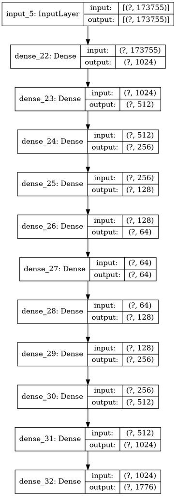

```python
import tensorflow
from tensorflow import keras
from keras.utils.vis_utils import plot_model

#Model
input_arr = keras.Input(shape=(173755,))
encoded = keras.layers.Dense(1024, activation='relu')(input_arr)
encoded = keras.layers.Dense(512, activation='relu')(encoded)
encoded = keras.layers.Dense(256, activation='relu')(encoded)
encoded = keras.layers.Dense(128, activation='relu')(encoded)
encoded = keras.layers.Dense(64, activation='relu', activity_regularizer= keras.regularizers.l1(10e-5))(encoded)

decoded = keras.layers.Dense(64, activation='relu')(encoded)
decoded = keras.layers.Dense(128, activation='relu')(decoded)
decoded = keras.layers.Dense(256, activation='relu')(decoded)
decoded = keras.layers.Dense(512, activation='relu')(decoded)
decoded = keras.layers.Dense(1024, activation='relu')(decoded)
decoded = keras.layers.Dense(1776, activation='relu')(decoded)

encoded_input = keras.Input(shape=(64,))

# Total model
autoencoder = keras.Model(input_arr, decoded)

# This model maps an input to its encoded representation
encoder = keras.Model(input_arr, encoded)
autoencoder.compile(optimizer='adam', loss='mse')

print(autoencoder.summary())
plot_model(autoencoder, to_file='autoencoder_dist.png', show_shapes=True, show_layer_names=True)
```

### Model with just dihedral angles between consecutive alpha carbons

```
Model: "model_6"
_________________________________________________________________
Layer (type)                 Output Shape              Param #
=================================================================
input_7 (InputLayer)         [(None, 589)]             0
_________________________________________________________________
dense_33 (Dense)             (None, 512)               302080
_________________________________________________________________
dense_34 (Dense)             (None, 256)               131328
_________________________________________________________________
dense_35 (Dense)             (None, 128)               32896
_________________________________________________________________
dense_36 (Dense)             (None, 64)                8256
_________________________________________________________________
dense_37 (Dense)             (None, 64)                4160
_________________________________________________________________
dense_38 (Dense)             (None, 128)               8320
_________________________________________________________________
dense_39 (Dense)             (None, 256)               33024
_________________________________________________________________
dense_40 (Dense)             (None, 512)               131584
_________________________________________________________________
dense_41 (Dense)             (None, 1024)              525312
_________________________________________________________________
dense_42 (Dense)             (None, 1776)              1820400
=================================================================
Total params: 2,997,360
Trainable params: 2,997,360
Non-trainable params: 0
_________________________________________________________________
None
```

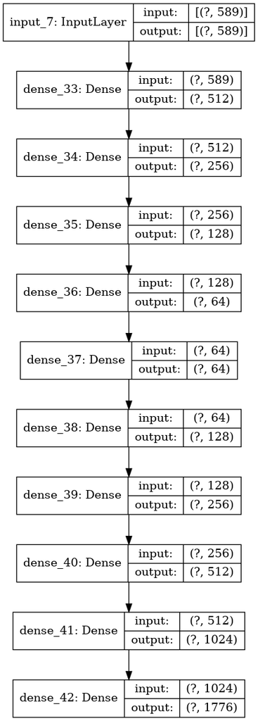

```python
# Model
input_arr = keras.Input(shape=(589,))
encoded = keras.layers.Dense(512, activation='relu')(input_arr)
encoded = keras.layers.Dense(256, activation='relu')(encoded)
encoded = keras.layers.Dense(128, activation='relu')(encoded)
encoded = keras.layers.Dense(64, activation='relu', activity_regularizer= keras.regularizers.l1(10e-5))(encoded)

decoded = keras.layers.Dense(64, activation='relu')(encoded)
decoded = keras.layers.Dense(128, activation='relu')(decoded)
decoded = keras.layers.Dense(256, activation='relu')(decoded)
decoded = keras.layers.Dense(512, activation='relu')(decoded)
decoded = keras.layers.Dense(1024, activation='relu')(decoded)
decoded = keras.layers.Dense(1776, activation='relu')(decoded)

encoded_input = keras.Input(shape=(64,))

# Total model
autoencoder = keras.Model(input_arr, decoded)

# This model maps an input to its encoded representation
encoder = keras.Model(input_arr, encoded)
autoencoder.compile(optimizer='adam', loss='mse')

print(autoencoder.summary())
plot_model(autoencoder, to_file='autoencoder_dihe.png', show_shapes=True, show_layer_names=True)
```

[3.0 points] Train a multi-task model (and/or) multi-modal model. You may use any method of multi-task or multi-modal training that you like.

# Multi-modal models

In our multi-modal models the latent space is of two layers post concatenation. This is because we want to enable the NN to learn combinations of pairwise alpha carbons distances and dihedral angles which can be potentially useful for the reconstruction of the 3D protein structure.

```python
# Split
contact_train, contact_test, dihe_train, dihe_test, xyz_train, xyz_test = train_test_split(values_dist, values_dihe, values_xyz, test_size=0.33, random_state=42)
```

```
Model: "model_8"
__________________________________________________________________________________________________
Layer (type)                    Output Shape         Param #     Connected to
==================================================================================================
input_9 (InputLayer)            [(None, 173755)]     0
__________________________________________________________________________________________________
dense_43 (Dense)                (None, 1024)         177926144   input_9[0][0]
__________________________________________________________________________________________________
input_10 (InputLayer)           [(None, 589)]        0
__________________________________________________________________________________________________
dense_44 (Dense)                (None, 512)          524800      dense_43[0][0]
__________________________________________________________________________________________________
dense_48 (Dense)                (None, 512)          302080      input_10[0][0]
__________________________________________________________________________________________________
dense_45 (Dense)                (None, 256)          131328      dense_44[0][0]
__________________________________________________________________________________________________
dense_49 (Dense)                (None, 256)          131328      dense_48[0][0]
__________________________________________________________________________________________________
dense_46 (Dense)                (None, 128)          32896       dense_45[0][0]
__________________________________________________________________________________________________
dense_50 (Dense)                (None, 128)          32896       dense_49[0][0]
__________________________________________________________________________________________________
dense_47 (Dense)                (None, 64)           8256        dense_46[0][0]
__________________________________________________________________________________________________
dense_51 (Dense)                (None, 64)           8256        dense_50[0][0]
__________________________________________________________________________________________________
concatenate (Concatenate)       (None, 128)          0           dense_47[0][0]
                                                                 dense_51[0][0]
__________________________________________________________________________________________________
dense_52 (Dense)                (None, 128)          16512       concatenate[0][0]
__________________________________________________________________________________________________
dense_53 (Dense)                (None, 64)           8256        dense_52[0][0]
__________________________________________________________________________________________________
dense_54 (Dense)                (None, 64)           4160        dense_53[0][0]
__________________________________________________________________________________________________
dense_55 (Dense)                (None, 128)          8320        dense_54[0][0]
__________________________________________________________________________________________________
dense_56 (Dense)                (None, 256)          33024       dense_55[0][0]
__________________________________________________________________________________________________
dense_57 (Dense)                (None, 512)          131584      dense_56[0][0]
__________________________________________________________________________________________________
dense_58 (Dense)                (None, 1024)         525312      dense_57[0][0]
__________________________________________________________________________________________________
dense_59 (Dense)                (None, 1776)         1820400     dense_58[0][0]
==================================================================================================
Total params: 181,645,552
Trainable params: 181,645,552
Non-trainable params: 0
__________________________________________________________________________________________________
None
```

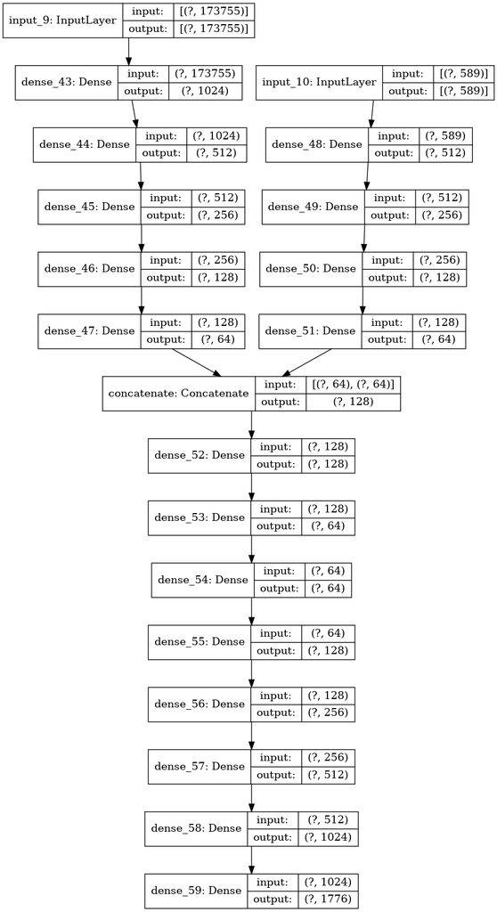

```python
# Multi-modal Model
input_dist = keras.Input(shape=(173755,))
encoded_dist = keras.layers.Dense(1024, activation='relu', kernel_initializer=keras.initializers.he_uniform())(input_dist)
encoded_dist = keras.layers.Dense(512, activation='relu', kernel_initializer=keras.initializers.he_uniform())(encoded_dist)
encoded_dist = keras.layers.Dense(256, activation='relu', kernel_initializer=keras.initializers.he_uniform())(encoded_dist)
encoded_dist = keras.layers.Dense(128, activation='relu', kernel_initializer=keras.initializers.he_uniform())(encoded_dist)
encoded_dist = keras.layers.Dense(64, activation='relu', kernel_initializer=keras.initializers.he_uniform())(encoded_dist)

input_dihe = keras.Input(shape=(589,))
encoded_dihe = keras.layers.Dense(512, activation='relu', kernel_initializer=keras.initializers.he_uniform())(input_dihe)
encoded_dihe = keras.layers.Dense(256, activation='relu', kernel_initializer=keras.initializers.he_uniform())(encoded_dihe)
encoded_dihe = keras.layers.Dense(128, activation='relu', kernel_initializer=keras.initializers.he_uniform())(encoded_dihe)
encoded_dihe = keras.layers.Dense(64, activation='relu', kernel_initializer=keras.initializers.he_uniform())(encoded_dihe)

x = keras.layers.Concatenate()([encoded_dist, encoded_dihe])
latent = keras.layers.Dense(128, activation='relu', kernel_initializer=keras.initializers.he_uniform(), activity_regularizer= keras.regularizers.l1(10e-5))(x)
latent = keras.layers.Dense(64, activation='relu', kernel_initializer=keras.initializers.he_uniform(), activity_regularizer= keras.regularizers.l1(10e-5))(latent)

decoded = keras.layers.Dense(64, activation='relu', kernel_initializer=keras.initializers.he_uniform())(latent)
decoded = keras.layers.Dense(128, activation='relu', kernel_initializer=keras.initializers.he_uniform())(decoded)
decoded = keras.layers.Dense(256, activation='relu', kernel_initializer=keras.initializers.he_uniform())(decoded)
decoded = keras.layers.Dense(512, activation='relu', kernel_initializer=keras.initializers.he_uniform())(decoded)
decoded = keras.layers.Dense(1024, activation='relu', kernel_initializer=keras.initializers.he_uniform())(decoded)
decoded = keras.layers.Dense(1776, activation='relu')(decoded)


# Total model
autoencoder = keras.Model(inputs=[input_dist, input_dihe], outputs=decoded)

# This model maps an input to its encoded representation
encoder = keras.Model(inputs=[input_dist, input_dihe], outputs=latent)

# Show model
print(autoencoder.summary())
plot_model(autoencoder, to_file='autoencoder_multimodal.png', show_shapes=True, show_layer_names=True)
```

The architecture of these models is identical to the one shown above. The main difference is the weight initializations. here we copied the weights from the single modal models. Specifically:

#### Model v2:

Only the weights for both encoders were initlialized using the trained weights from the single mode models

#### Model v3:

On top of the weights for both encoders, the weights in the decoder were initialized using the trained weights of the decoder from the best single-mode model )the one with the pairwise alpha carbon distances as shown below).

The way we transfer the weights is shown below. (The weights transfer is done before compilation)

```python
# Get weights from pre-loaded model
# First encoder
autoencoder.get_layer('dense').set_weights(encoder_dist.get_layer('dense').get_weights())
autoencoder.get_layer('dense_1').set_weights(encoder_dist.get_layer('dense_1').get_weights())
autoencoder.get_layer('dense_2').set_weights(encoder_dist.get_layer('dense_2').get_weights())
autoencoder.get_layer('dense_3').set_weights(encoder_dist.get_layer('dense_3').get_weights())
autoencoder.get_layer('dense_4').set_weights(encoder_dist.get_layer('dense_4').get_weights())

#Second encoder
autoencoder.get_layer('dense_5').set_weights(encoder_dihe.get_layer('dense').get_weights())
autoencoder.get_layer('dense_6').set_weights(encoder_dihe.get_layer('dense_1').get_weights())
autoencoder.get_layer('dense_7').set_weights(encoder_dihe.get_layer('dense_2').get_weights())
autoencoder.get_layer('dense_8').set_weights(encoder_dihe.get_layer('dense_3').get_weights())


#Decoder
autoencoder.get_layer('dense_11').set_weights(autoencoder_dist.get_layer('dense_5').get_weights())
autoencoder.get_layer('dense_12').set_weights(autoencoder_dist.get_layer('dense_6').get_weights())
autoencoder.get_layer('dense_13').set_weights(autoencoder_dist.get_layer('dense_7').get_weights())
autoencoder.get_layer('dense_14').set_weights(autoencoder_dist.get_layer('dense_8').get_weights())
autoencoder.get_layer('dense_15').set_weights(autoencoder_dist.get_layer('dense_9').get_weights())
autoencoder.get_layer('dense_16').set_weights(autoencoder_dist.get_layer('dense_10').get_weights())
```

### Multi model v4: encoders and decoders weight initialization frm single-modes Networks + dropout

```
Model: "model_12"
__________________________________________________________________________________________________
Layer (type)                    Output Shape         Param #     Connected to
==================================================================================================
input_13 (InputLayer)           [(None, 173755)]     0
__________________________________________________________________________________________________
dense_77 (Dense)                (None, 1024)         177926144   input_13[0][0]
__________________________________________________________________________________________________
dropout_16 (Dropout)            (None, 1024)         0           dense_77[0][0]
__________________________________________________________________________________________________
input_14 (InputLayer)           [(None, 589)]        0
__________________________________________________________________________________________________
dense_78 (Dense)                (None, 512)          524800      dropout_16[0][0]
__________________________________________________________________________________________________
dense_82 (Dense)                (None, 512)          302080      input_14[0][0]
__________________________________________________________________________________________________
dropout_17 (Dropout)            (None, 512)          0           dense_78[0][0]
__________________________________________________________________________________________________
dropout_21 (Dropout)            (None, 512)          0           dense_82[0][0]
__________________________________________________________________________________________________
dense_79 (Dense)                (None, 256)          131328      dropout_17[0][0]
__________________________________________________________________________________________________
dense_83 (Dense)                (None, 256)          131328      dropout_21[0][0]
__________________________________________________________________________________________________
dropout_18 (Dropout)            (None, 256)          0           dense_79[0][0]
__________________________________________________________________________________________________
dropout_22 (Dropout)            (None, 256)          0           dense_83[0][0]
__________________________________________________________________________________________________
dense_80 (Dense)                (None, 128)          32896       dropout_18[0][0]
__________________________________________________________________________________________________
dense_84 (Dense)                (None, 128)          32896       dropout_22[0][0]
__________________________________________________________________________________________________
dropout_19 (Dropout)            (None, 128)          0           dense_80[0][0]
__________________________________________________________________________________________________
dropout_23 (Dropout)            (None, 128)          0           dense_84[0][0]
__________________________________________________________________________________________________
dense_81 (Dense)                (None, 64)           8256        dropout_19[0][0]
__________________________________________________________________________________________________
dense_85 (Dense)                (None, 64)           8256        dropout_23[0][0]
__________________________________________________________________________________________________
```

[output cut: 27 more lines]

```
dense_91 (Dense)                (None, 512)          131584      dropout_29[0][0]
__________________________________________________________________________________________________
dropout_30 (Dropout)            (None, 512)          0           dense_91[0][0]
__________________________________________________________________________________________________
dense_92 (Dense)                (None, 1024)         525312      dropout_30[0][0]
__________________________________________________________________________________________________
dropout_31 (Dropout)            (None, 1024)         0           dense_92[0][0]
__________________________________________________________________________________________________
dense_93 (Dense)                (None, 1776)         1820400     dropout_31[0][0]
==================================================================================================
Total params: 181,645,552
Trainable params: 181,645,552
Non-trainable params: 0
__________________________________________________________________________________________________
None
```

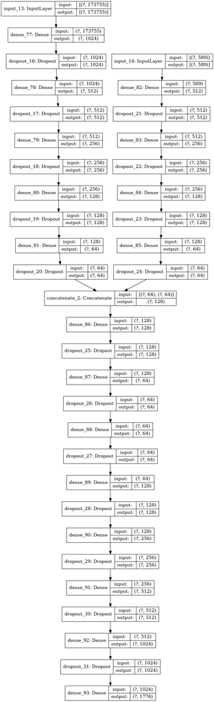

```python
# Multi-modal Model
input_dist = keras.Input(shape=(173755,))
encoded_dist = keras.layers.Dense(1024, activation='relu')(input_dist)
encoded_dist = keras.layers.Dropout(0.2)(encoded_dist)
encoded_dist = keras.layers.Dense(512, activation='relu')(encoded_dist)
encoded_dist = keras.layers.Dropout(0.2)(encoded_dist)
encoded_dist = keras.layers.Dense(256, activation='relu')(encoded_dist)
encoded_dist = keras.layers.Dropout(0.2)(encoded_dist)
encoded_dist = keras.layers.Dense(128, activation='relu')(encoded_dist)
encoded_dist = keras.layers.Dropout(0.2)(encoded_dist)
encoded_dist = keras.layers.Dense(64, activation='relu')(encoded_dist)
encoded_dist = keras.layers.Dropout(0.2)(encoded_dist)

input_dihe = keras.Input(shape=(589,))
encoded_dihe = keras.layers.Dense(512, activation='relu')(input_dihe)
encoded_dihe = keras.layers.Dropout(0.2)(encoded_dihe)
encoded_dihe = keras.layers.Dense(256, activation='relu')(encoded_dihe)
encoded_dihe = keras.layers.Dropout(0.2)(encoded_dihe)
encoded_dihe = keras.layers.Dense(128, activation='relu')(encoded_dihe)
encoded_dihe = keras.layers.Dropout(0.2)(encoded_dihe)
encoded_dihe = keras.layers.Dense(64, activation='relu')(encoded_dihe)
encoded_dihe = keras.layers.Dropout(0.2)(encoded_dihe)

x = keras.layers.Concatenate()([encoded_dist, encoded_dihe])
latent = keras.layers.Dense(128, activation='relu', activity_regularizer= keras.regularizers.l1(10e-5))(x)
latent = keras.layers.Dropout(0.2)(latent)
latent = keras.layers.Dense(64, activation='relu', activity_regularizer= keras.regularizers.l1(10e-5))(latent)
latent = keras.layers.Dropout(0.2)(latent)

decoded = keras.layers.Dense(64, activation='relu')(latent)
decoded = keras.layers.Dropout(0.2)(decoded)
decoded = keras.layers.Dense(128, activation='relu')(decoded)
decoded = keras.layers.Dropout(0.2)(decoded)
decoded = keras.layers.Dense(256, activation='relu')(decoded)
decoded = keras.layers.Dropout(0.2)(decoded)
decoded = keras.layers.Dense(512, activation='relu')(decoded)
decoded = keras.layers.Dropout(0.2)(decoded)
decoded = keras.layers.Dense(1024, activation='relu')(decoded)
decoded = keras.layers.Dropout(0.2)(decoded)
decoded = keras.layers.Dense(1776, activation='relu')(decoded)

# Total model
autoencoder = keras.Model(inputs=[input_dist, input_dihe], outputs=decoded)

# This model maps an input to its encoded representation
encoder = keras.Model(inputs=[input_dist, input_dihe], outputs=latent)

#Compile
autoencoder.compile(optimizer='adam', loss='mse')

# Show model
print(autoencoder.summary())
plot_model(autoencoder, to_file='autoencoder_multimodal.png', show_shapes=True, show_layer_names=True)
```

[2.0 points] Report the results using the evaluation procedure that you argued for at the beginning of the lab.

# (Training) Performance

The training performance can be seen from the plots below. Moreover, In this study the validation loss was used as a metric to evaluate the performance of the model. In fact the Mean squared error was used as it provide a interpretable metric to evaluate how different the predicted structure is from the original 3d structure.

### Single models performances

```python
ca_only = pd.read_pickle('dist_train_hist.pkl')
dihedral_only = pd.read_pickle('dihe_train_hist.pkl')
```

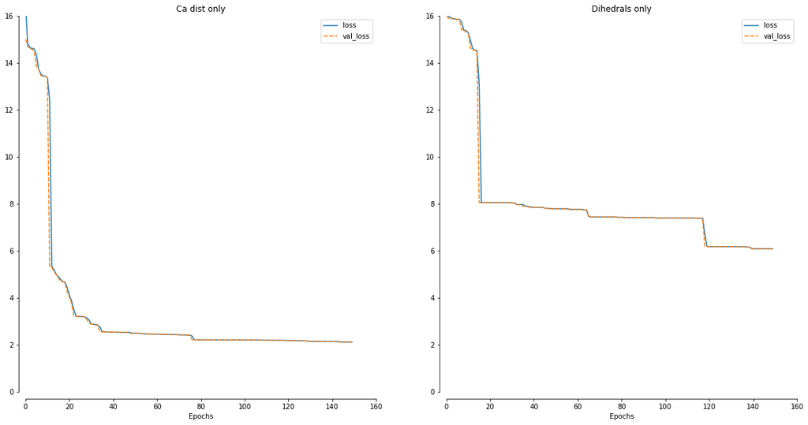

```python
plt.figure()
fig, axs = plt.subplots(nrows=1, ncols=2, figsize=[20,10])
sns.lineplot(ax=axs[0], data=ca_only)
sns.lineplot(ax=axs[1], data=dihedral_only)

axs[0].set_ylim(0, 16)
axs[1].set_ylim(0, 16)

axs[0].set_xlim(0, 160)
axs[1].set_xlim(0, 160)

sns.despine(offset=10, trim=True)

axs[0].set_title('Ca dist only')
axs[1].set_title('Dihedrals only')

axs[0].set_xlabel('Epochs')
axs[1].set_xlabel('Epochs')

plt.show()
```

We observe that the loss for the models using the pariwise distances between the alpha carbons achieved better performances compared to the model which uses only dihedrals. This was expected as dihedrals can be very good at describing local struture (secondary) but lack information to define the global structure (tertiary) of the protein.

### Multi-Modal models performances

```python
# Load training and validation losses for all models
multi = pd.read_pickle('train_hist_multi.pkl')
multi_enc_preloaded = pd.read_pickle('train_hist_multi_enc_preloaded.pkl')
multi_all_preloaded = pd.read_pickle('train_hist_multi_dec_preloaded.pkl')
multi_preloaded_dropout = pd.read_pickle('train_hist_multi_preloaded_dropout.pkl')
```

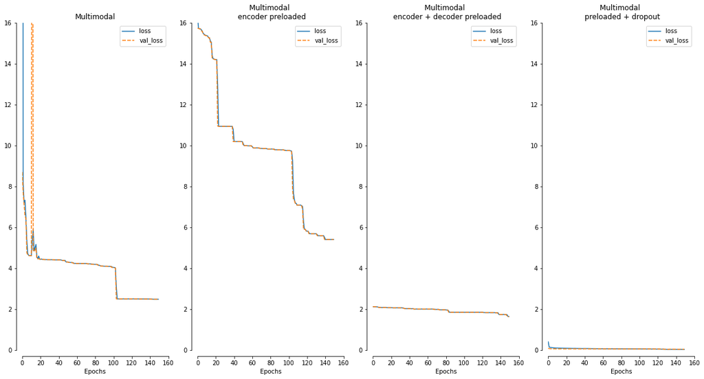

```python
plt.figure()
fig, axs = plt.subplots(nrows=1, ncols=4, figsize=[20,10])
sns.lineplot(ax=axs[0], data=multi)
sns.lineplot(ax=axs[1], data=multi_enc_preloaded)
sns.lineplot(ax=axs[2], data=multi_all_preloaded)
sns.lineplot(ax=axs[3], data=multi_preloaded_dropout)

axs[0].set_ylim(0, 16)
axs[1].set_ylim(0, 16)
axs[2].set_ylim(0, 16)
axs[3].set_ylim(0, 16)

axs[0].set_xlim(0, 160)
axs[1].set_xlim(0, 160)
axs[2].set_xlim(0, 160)
axs[3].set_xlim(0, 160)

sns.despine(offset=10, trim=True)

axs[0].set_title('Multimodal')
axs[1].set_title('Multimodal \n encoder preloaded')
axs[2].set_title('Multimodal \n encoder + decoder preloaded')
axs[3].set_title('Multimodal \n preloaded + dropout')

axs[0].set_xlabel('Epochs')
axs[1].set_xlabel('Epochs')
axs[2].set_xlabel('Epochs')
axs[3].set_xlabel('Epochs')
plt.show()
```

As we can see the basic model does not improve the performances of the best single model. This might be due to the limit number of epochs. In fact in this model we have a greater number of weights, which might need more epochs for better results. Interestingly, when we loaded the weights of the encoders (the different modalities) we observe the worsening of the performance. When the weights of the decoder of the best single mode were used for initialization, we observe a clear improvement of the performance, and slight improvement compared to the best single model. We cannot assess however this improvement to be due to the multi-modality. Lastly, when we added dropout to all the layers, we observe a drastic improvement of the model performance, whose losses for validation and training go to a minimum of 0.04.

[2.0 points] Finally, you have freedom to perform any other analysis you want. Please explain what analysis you are investigating and why.

# Additional analyses

In this section we are going to do some preliminary analyses on how similar the reconstructed structures to the oeriginal frames. We will start with a visual investigation to check the overall conformation is preserved and if the differences in distance between secondary structures in different frames are captured. This change of distances distances are critical for the function of this protein. After checking that the distances between secondary structures are conserved, we investigated the assignment of secondary structures themselves. Lastly we checked the latent space of our best model to investigate if the separation and overlap of the different states of the protein are meaningful.

## Visualization of the reconstructed structures

Some functions needed to convert the numpy file from the NN outpuut to a readable format for visualization

#### Build 3D structure files from numpy output file

```python
def build_molecule(mol, name):
    f = open(name+'.xyz', 'w')
    f.write(str(len(mol))+'\n')
    f.write('reconstructed molecule \n')

    for i in mol:
        x, y, z = str(i[0]*10), str(i[1]*10), str(i[2]*10)
        f.write('C       '+x+'      '+y+'      '+z+'\n')
    f.close()

    print(name +' file ready')
```

#### Get atomic information from template file

```python
# the folowing extract the information of the atoms used in the analysis (alpha carbons) needed to build a PDB (protein data bank) format file
ref = md.load('/users/ftrozzi/scratch/work/covid/MD/analysis/0-trajs/traj_0.nc', top='/users/ftrozzi/scratch/work/covid/MD/analysis/0-trajs/traj_0.prmtop')
topo = ref.topology
table, bonds = topo.to_dataframe()
indx = topo.select('(resid 0 to 591) and (name CA)')
traj = ref.atom_slice(indx)
topo = traj.topology
```

#### Example of creating pdb for visualization

```python
#Extract pdf format for visualizrion
predicted_0 = np.load('../predicted_ex.npy').reshape(592, 3)
build_molecule(predicted_0, 'predicted_ex')
predicted_xyz_0 = md.load_xyz('predicted_eg.xyz', top=topo)
predicted_xyz_0.save_pdb('predicted_eg.pdb')
```

### Comparison of same frame original-vs-reconstructed.

For this VERY qualitative structural analysis we compared the original and reconstructure structures for the same frame. In the figure below the red structure is the original, while in blue the reconstructed frame. We can see that overall the secondary structures overlap very well. Especially in the back of the structure we have a perfect overlap for most of the helices. We noticed that the wrong distances are assigned for the flexible parts of the protein (coils) and the helices in the from wich are known to be flexible for this protein.

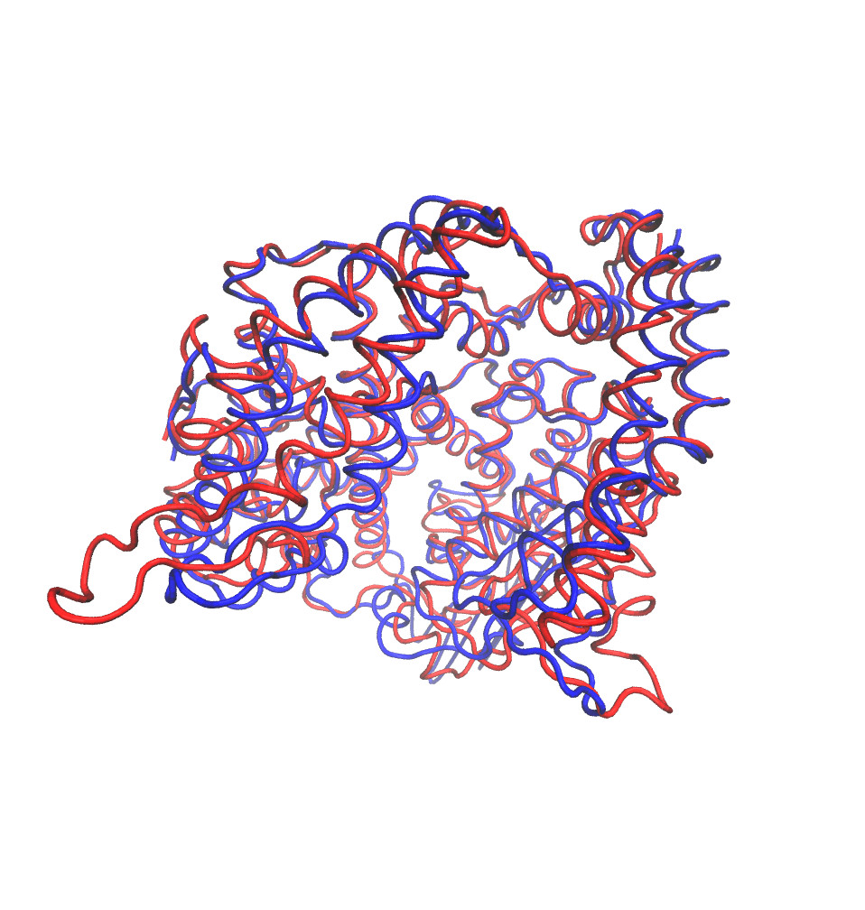

```python
Image(filename='test_vs_pred.jpg')
```

## Comparing two reconstructed frames

We compared different predicted frames to check if known functional changes in the distances between secondary structures are conserved. If yes, this represent a (again VERY qualitative) indication that our multi-model NN is keeping crucial information related to protein function in its "conformational" latent space. From the visual inspection of the original frames we picked two frames which clearly show the characteristic changes between the distances of the secondary structure. This characteristic change is the opening/closing of the helices in the front(picture below). We can see that in our reconstructured structures the opening and closing of these helices is perfectly captured!

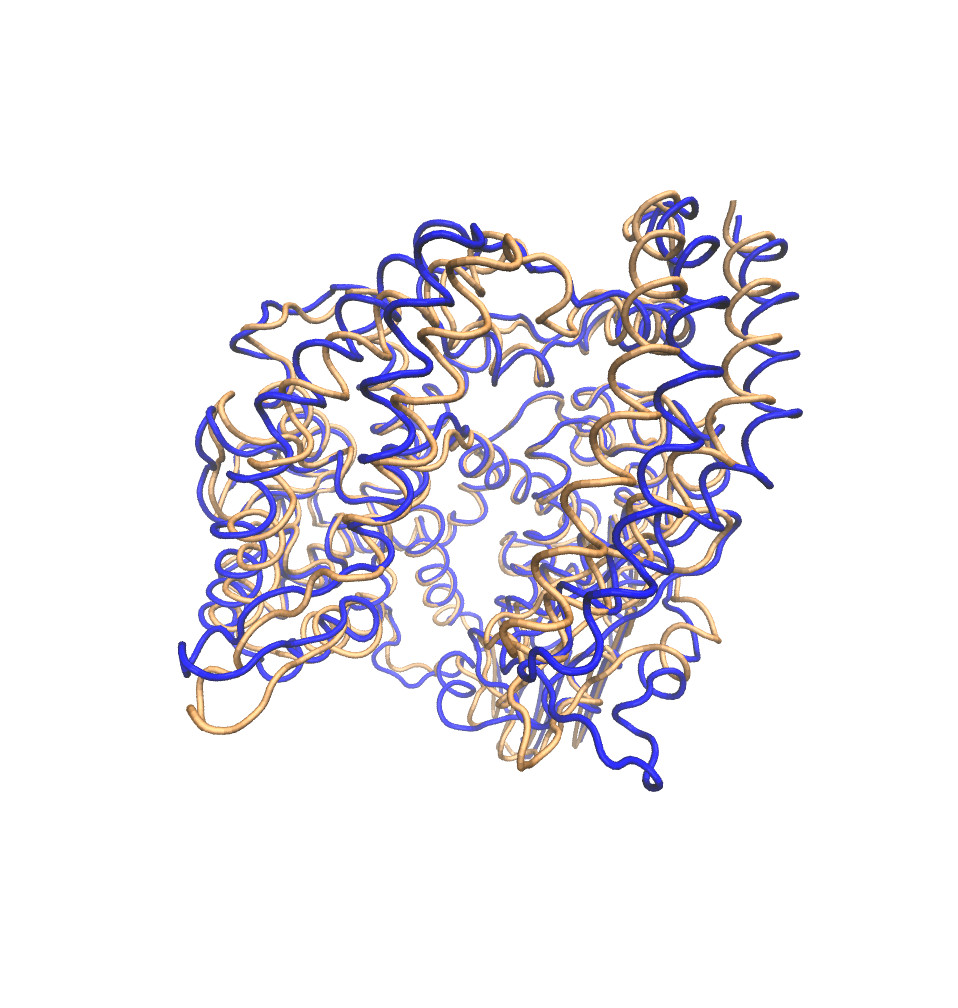

```python
Image(filename='open-vs-closed_pred.jpg')
```

## Secondary structure assignment evaluation

We observed ho the spatial relation between secondary structures is kept in the reconstructure. But how well are the secondary structures preserved? We can investigate it by using a secondary structure assignment tool to see if in the predicted structure the secondary structures formed are well assigned. For this analysis we used PCASSO, a tool for the assignment of secondary structure based on alpha carbon position (the output of our model). We want to compare if the output of our model is capable to retain the secondary structure, which would demonstrate that the latent space of our model is preserving this crucial type of information. the tool is available at: https://brooks.chem.lsa.umich.edu/index.php?pcassoserver=submit

An example of output is given below:

predicted_0.pdb 0 A:GLU1.CA C A:GLU2.CA H A:GLN3.CA H A:ALA4.CA H A:LYS5.CA H A:THR6.CA H A:PHE7.CA H A:LEU8.CA H A:ASP9.CA H A:LYS10.CA H A:PHE11.CA H A:ASN12.CA H A:HIS13.CA H A:GLU14.CA H A:ALA15.CA H A:GLU16.CA H A:ASP17.CA H A:LEU18.CA H A:PHE19.CA H A:TYR20.CA H A:GLN21.CA H A:SER22.CA H A:SER23.CA H A:LEU24.CA H A:ALA25.CA H A:SER26.CA H A:TRP27.CA H A:ASN28.CA H A:TYR29.CA H A:ASN30.CA H A:THR31.CA H A:ASN32.CA C A:ILE33.CA C A:THR34.CA C A:GLU35.CA H A:GLU36.CA H A:ASN37.CA H A:VAL38.CA H A:GLN39.CA H A:ASN40.CA H A:MET41.CA H A:ASN42.CA H A:ASN43.CA H A:ALA44.CA H A:GLY45.CA H A:ASP46.CA H A:LYS47.CA H A:TRP48.CA H A:SER49.CA H A:ALA50.CA H A:PHE51.CA H A:LEU52.CA H A:LYS53.CA H A:GLU54.CA H A:GLN55.CA H A:SER56.CA H A:THR57.CA H A:LEU58.CA H A:ALA59.CA H A:GLN60.CA H A:MET61.CA C A:TYR62.CA C A:PRO63.CA C A:LEU64.CA H A:GLN65.CA H A:GLU66.CA H A:ILE67.CA C A:GLN68.CA C A:ASN69.CA C A:LEU70.CA H A:THR71.CA H A:VAL72.CA H A:LYS73.CA H A:LEU74.CA H A:GLN75.CA H A:LEU76.CA H A:GLN77.CA H A:ALA78.CA H A:LEU79.CA H A:GLN80.CA C A:GLN81.CA C A:ASN82.CA C A:GLY83.CA C A:SER84.CA C A:SER85.CA C A:VAL86.CA C A:LEU87.CA C A:SER88.CA C A:GLU89.CA H A:ASP90.CA H A:LYS91.CA H A:SER92.CA H A:LYS93.CA H A:ARG94.CA H A:LEU95.CA H A:ASN96.CA H A:THR97.CA H A:ILE98.CA H A:LEU99.CA H ...

With H being Helices, E being B-Sheets, and C being Coils.

```python
# we saved the output of this analysis as text files
# same frames used for the visual inspection were used
original = open('test_ss.txt', 'r')
predicted = open('best_pred_ss.txt', 'r')

for line in original:
    sp = line.split()
    original_ss = np.array(sp[1::2])[1:]

for line in predicted:
    sp = line.split()
    predicted_ss = np.array(sp[1::2])[1:]

c= 0
divergent = []
for i in range(len(predicted_ss)):
    if predicted_ss[i] == original_ss[i]:
        c += 1
    else:
        divergent.append([original_ss[i], predicted_ss[i]])

print('Correct assignment of secondary stucture')
correct_pred_percentage = c/len(predicted_ss)*100
print(correct_pred_percentage)

# Secondary structure involvment in wrong assignment'
C, H, E = 0, 0, 0
for pair in divergent:
    for i in pair:
        if i == 'C':
            C += 1
        elif i == 'H':
            H += 1
        elif i == 'E':
            E += 1
wrong_ss = [C, H, E]
```

```
Correct assignment of secondary stucture
90.35532994923858
```

We can see that over 90% of the residues are assigned the correct secondary structure (compared with the assignment of the original structure)! It would be now interesting to see if there is some systematic mis-assignment. A systematic error would give us an indication of a problem of our model in reconstructing a certain type of structure given the features used.

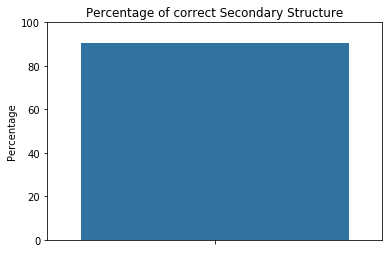

```python
# Plots results
sns.barplot(y=correct_pred_percentage)
plt.ylabel('Percentage')
plt.ylim(0, 100)
plt.title('Percentage of correct Secondary Structure')
plt.show()
```

From the plot below we observe that in all cases of mis-assignment the residues in the coils were involved. This comes to no surprise as this part of the protein are the most disorganized and flexible regions. This means that they adopt a wide range of values of distances and angles and can momentarly adopt values typical of helices and beta sheets. A further analysis should be checking weather assignment of the secondary structure for the residues involved in the mis-assignment strongly changes even within the original structures.

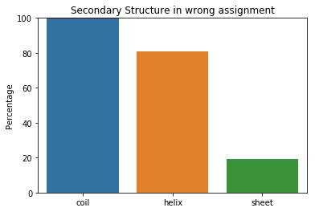

```python
for i in range(len(wrong_ss)):
    wrong_ss[i] = wrong_ss[i]/len(divergent)*100

x = ['coil', 'helix', 'sheet']
sns.barplot(x=x, y=wrong_ss)
plt.ylabel('Percentage')
plt.ylim(0, 100)
plt.title('Secondary Structure in wrong assignment')
plt.show()
```

## Analysis of the latent space

Ultimately we want to obtain a good latent space that we can project to obtain a visual conformational space of the protein. To do so we reduced the latent space obtained using UMAP. We want to check if the different states of this protein are well projected and try to rationalize potential overlaps/separation to assess the goodness of he conformational space.

```python
# Extract latent space from encoder
# Since we want to study the conformational space arose by our data, all dataset was used to visualize the latent space
# A more systematic investigation of the latent space for training and test set will be done in the future, pinky swear
latent = encoder_best.predict([values_dist, values_dihe])
```

```python
# Project conformational space into 2D
import umap
reducer = umap.UMAP(min_dist=1, n_neighbors=100, n_components=2, metric='correlation')
reduced =  reducer.fit_transform(latent)
```

```python
# Create list for labeling
states = []
for i in range(len(latent)):
    if i < 15000:
        states.append('6m17_apo')
    if i > 14999 and i < 30000:
        states.append('6m17_apo_Zn')
    if i > 29999 and i < 45000:
        states.append('6m18_apo_Zn')
    if i > 44999 and i < 60000:
        states.append('6m18_apo')
    if i > 59999 and i < 75000:
        states.append('6m1d_apo')
    if i > 74999 and i < 90000:
        states.append('6m1d_apo_Zn')
```

```python
# Make the date nice and tidy
df_reduced = pd.DataFrame(reduced, columns=['UMAP1', 'UMAP2'])
df_reduced['Structure'] = states
df_reduced.head()
```

```python
# Plot
plt.figure(figsize=[10,10])
sns.scatterplot(data=df_reduced, x='UMAP1', y='UMAP2', hue=df_reduced.Structure.tolist(), s=20)
plt.show()
```

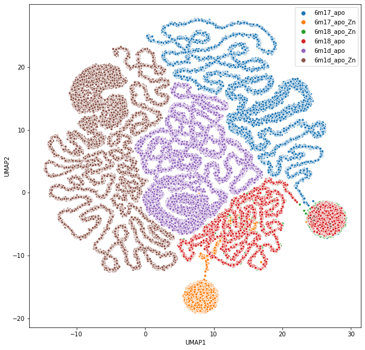

```python
Image(filename='lab3_umap.png')
```

From the plot above we observe that the different states of the protein are well separated for the most part. Whilst some overlapping is to be expected as different states should explore some of the same energy minima, the circular overlap are quite difficult to rationalize. To be frank while it is encouraging, more work should be done to obtain a better conformational space. The problem is defining better, which leads to... our final remarks

# Final remarks

Although they were on the back of the structure, some atoms were misplaced in the predicted structures. We noticed that the problem strongly worsened for our single modality models. We still have to investigate if the dropout was what helped the most or the usage of multi-modalities. From the plots of the models trained so far it seems the first, but since we don;t have the data for the single-mode models with dropout we cannot exclude the latter. Another potential cause might be an error when featurizing the data. Regardless the reason, this odd placing fr this atoms in the structure might be the cause for those conformational space oddities. To be fair we used this data because it was the one Francesco was playing around, for publication we might want an easier and better characterized protein systems for an easy interpretation of, and therefore validation of quality of, the projected conformational space.

Overall, we are going to test to other systems, potentially include more features (modalities) which might help defining the conformational space, switch from qualitative to quantitative analysis (or at least include more structure in the qualitative analysis to get some statistics), and keep working in improving the architecture. On the latter, besides keep investigating the dropouts vs modalities effects discussed above, we are planning to implement another new scheme to input the alpha carbon distances information into the latent space which we would like to discuss with you in the near future!

To conclude, we managed to reconstruct a protein 3-Dimensional structure using only its geometrical features. Whilst the predicted structures were not perfect, the secondary structures, their spatial relations (tertieary structure), and the biologically relevant structural changes were all present in the predicted structure, and therefore well captured in the conformational latent space! Given the great complexity of this particular protein,( at least compared to other protein systems) all and all we are pretty impressed with the results!